# Eksamens projekt

## 1

En mulig forklaring for disse lønforskelle er divergerende afkast på investeringer i forskellige længerevarende uddannelser. Uddannelsesvalg er præget af segregering: kun få videregående uddannelser har et optag af studerende med lige andele af mænd af kvinder. Kønsforskelle i uddannelsesvalg kunne skyldes divergerende præferencer kønnene imellem (Hakim 2000), men ‘…individual preferences (and thus choices) are always socially embedded and constrained, and may be shaped by unjust background conditions, as well as by habit and engrained normative assumptions.’ (Crompton 2007: 234). Socialt determinerede kønspræferencer i forhold til uddannelse har potentiale til at cementere lønforskelle kønnene imellem på trods af samme resulterende niveau af human kapital. Derfor bør det undersøges, hvorvidt der foreligger en tendens blandt kvinder til at søge mod længerevarende videregående uddannelser, der leder til relativt lavere lønninger, og en tendens blandt mænd til at søge mod længerevarende videregående uddannelser, der resulterer i relativt højere lønninger. Hvis uddannelser med overrepræsentation af kvinder generelt leder til lavere lønninger, kan det både skyldes kønsforskelle i socialt afgrænsede præferencer, i.e. kvinder søger aktivt mod disse lavere lønnet uddannelser, eller lønforskelle opstået grundet feminisering af bestemte faggrupper. Øget feminisering af faggrupper resulterer ofte i lavere lønninger for disse grupper, grundet for eksempel diskrimination eller over-crowding (Rubery 2015; Bergmann 1974).

Med kønsopdelt data for ansøgerantal samt optagne studerende på længere videregående uddannelse er det muligt at bestemme udstrækningen af kønssegregering i uddannelsesvalg. Ydermere, gør løndata for færdige kandidater det muligt at bestemme, hvorvidt der forefindes en sammenhæng mellem kønssegregering blandt optagne studerende og forventet løn efter afsluttet uddannelse. Sluttelig analyseres det, hvorvidt forventet lønniveau kan forudsige kønsfordelingen blandt ansøgere på længere videregående uddannelser.

## GRAF 1

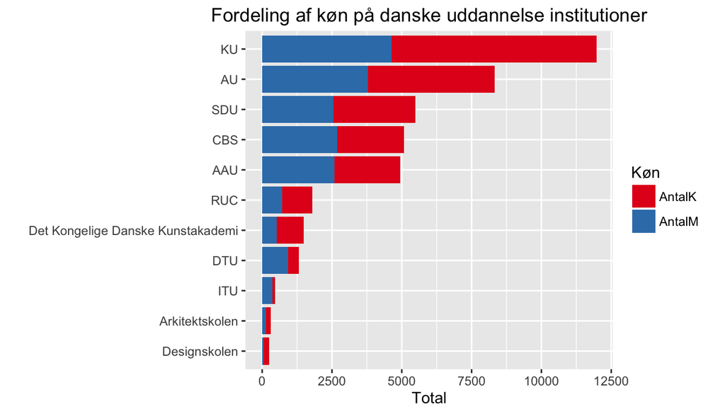

## GRAF 2

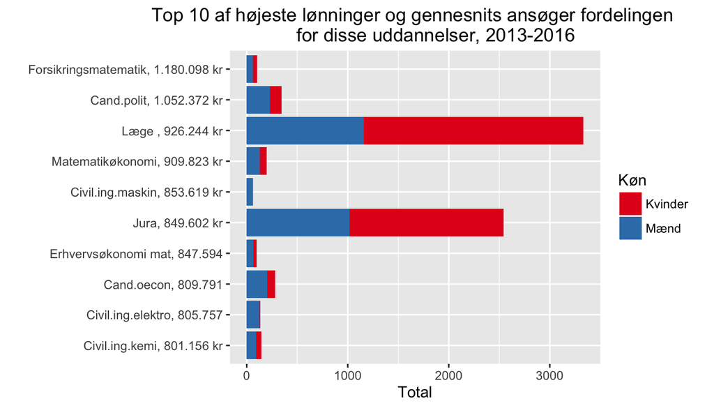

## GRAF 3

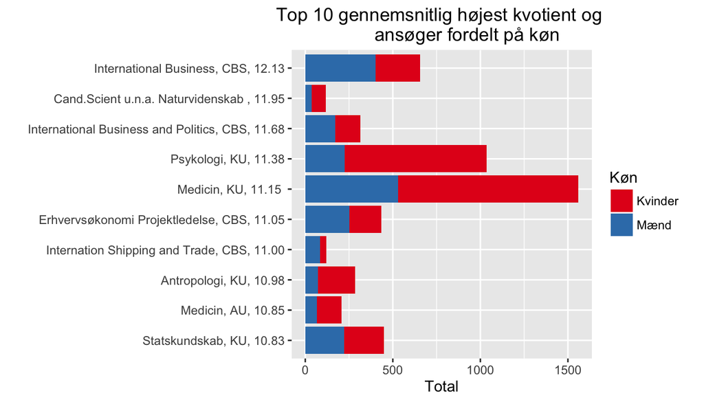

## GRAF 4

[figure not shown]

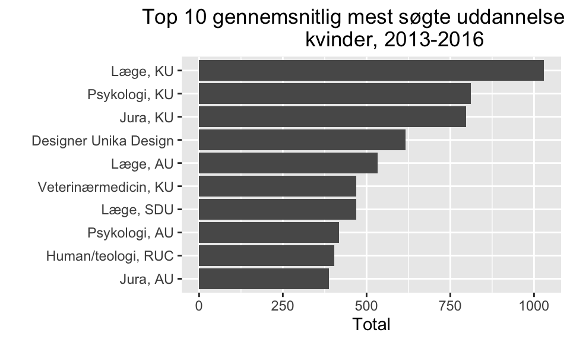

Logit

0

.

828***

0

.

755***

0

.

758***

0

.

238***

0

.

350***

0

.

271***

0

.

274***

.

.

(0

.

(0

.

(0

.

(0

.

(0

.

(0

.

.

035***

−0

.

038***

−0

.

037***

−0

.

036***

−0

.

035***

−0

.

042***

−0

.

040***

−0

.

039***

(0

.

(0

.

(0

.

(0

.

(0

.

(0

.

(0

.

(0

.

−0

.

175***

−0

.

169***

−0

.

156***

−0

.

174***

−0

.

172***

−0

.

157***

(0

.

(0

.

(0

.

(0

.

(0

.

(0

.

−0

.

038***

−0

.

016***

−0

.

013***

−0

.

042***

−0

.

018*

−0

.

016*

(0

.

(0

.

(0

.

(0

.

(0

.

(0

.

−0

.

279***

−0

.

250***

−0

.

256***

−0

.

291***

−0

.

264***

−0

.

270***

(0

.

(0

.

(0

.

(0

.

(0

.

(0

.

0

.

100***

0

.

072***

0

.

104***

0

.

109***

0

.

077***

0

.

111***

(0

.

(0

.

(0

.

(0

.

(0

.

(0

.

−0

.

080***

−0

.

060***

−0

.

062***

−0

.

085***

−0

.

065***

−0

.

067***

(0

.

(0

.

(0

.

(0

.

(0

.

(0

.

−0

.

056***

−0

.

033***

−0

.

035***

−0

.

057***

−0

.

034***

−0

.

036***

(0

.

(0

.

(0

.

(0

.

(0

.

(0

.

−0

.

017***

−0

.

018***

−0

.

011***

−0

.

016*

−0

.

019*

−0

.

011

(0

.

(0

.

(0

.

(0

.

(0

.

(0

.

−0

.

281***

−0

.

249***

−0

.

249***

−0

.

295***

−0

.

264***

−0

.

264***

(0

.

(0

.

(0

.

(0

.

(0

.

(0

.

0

.

167***

0

.

132***

0

.

145***

0

.

184***

0

.

142***

0

.

158***

(0

.

(0

.

(0

.

(0

.

(0

.

(0

.

0

.

010***

0

.

011***

0

.

011***

0

.

011***

(0

.

(0

.

(0

.

(0

.

−0

.

000***

−0

.

000***

(0

.

(0

.

116535

116535

116535

116535

116535

116535

116535